# Lab #3

Jung Ho Suh

*Part one: Extracting and loading data*

```
1. Go to https://gssdataexplorer.norc.org/
2. Click Search variable
3. Search “happy”; click add to cart; go back. Repeat for “marital status”, “highest year of school completed”, “respondents sex”, “political party affiliation”, and other variables (you decide)
4. After you finished adding the variables, click Actions – Save to Project
5. Register an account
6. Click Default Project
7. Click Actions – Extract data
8.  Name your extract (e.g., extract1) – click NEXT;
    ADD ALL variables – click NEXT;
    click NEXT;
    Check Excel Workbook (data + metadata) and Excel Workbook (metadata only), and leave all others unchecked;
    CREATE EXTRACT
9. Wait for the extract to be ready in a few minutes, and then download an archive file.
10. Extract the archive file (ending with .tar.gz). Windows users: You may need 7-Zip
11. Load the Excel file into R, using
```

```r
install.packages('readxl', repo="http://cran.rstudio.com/")
install.packages("tidyverse", repo="http://cran.rstudio.com/")
dat <- readxl::read_xls('GSS.xls')
```

**Part two: Exploration**

Use ggplot2 to create the plots, and dplyr to manipulate the data frame as much as possible. You may want to rename the columns of the data frame for your convenience using rename in dplyr.

```r
library(dplyr)
dat <- readxl::read_xls('GSS.xls')
newdat <- dat %>%  rename('YEAR' = 'Gss year for this respondent',
                'ID' = 'Respondent id number',
                'MARITAL' = 'Marital status',
                'SCHYEAR' = 'Highest year of school completed',
                'SEX' = 'Respondents sex',
                'POLIPARTY' = 'Political party affiliation',
                'HAPPINESS' = 'General happiness',
                'BALLOT' = 'Ballot used for interview')

newdat <- newdat[!newdat$SCHYEAR  %in% c('No answer', 'Don\'t know'),]
```

Removed ‘No answer’ and ‘Don’t know’ from SCHYEAR(Year attended to school) and made the basis for consider the SCHYEAR as numeric(integer). Because of those two exceptions, SCHYEAR is considered character right now.

**1. Find the average years of education for the respondents with each marital status. Arrange your output in a meaningful order and print. Describe any patterns you find.**

```r
library(dplyr)

newdat %>%
  mutate(SCHYEAR = as.numeric(SCHYEAR)) %>%
  group_by(MARITAL) %>%
  summarize(meanEdu = mean(SCHYEAR, na.rm=TRUE)) %>%
  arrange(meanEdu)
```

```
## # A tibble: 7 x 2
##   MARITAL       meanEdu
##   <chr>           <dbl>
## 1 Widowed          11.2
## 2 Separated        11.9
## 3 Married          13.0
## 4 Divorced         13.1
## 5 Never married    13.4
## 6 No answer        15.5
## 7 <NA>            NaN
```

Made a table of mean of education by Marital status. It is ordered by average eduction duration and you can see that Widowed, Separated people have relatively less education compared to Never married people.

**2. Create a single data frame containing records for the better educated respondents with each marital status. A “better educated” respondent is someone who has strictly more years of education than the average among those with the same marital status. Print the structure of the data frame.**

```r
library(dplyr)

filtered_YEAR <- newdat %>%
  mutate(SCHYEAR = as.numeric(SCHYEAR)) %>%
  group_by(MARITAL) %>%
  filter(SCHYEAR > mean(SCHYEAR, na.rm=TRUE)) %>%
  arrange(MARITAL)

str(filtered_YEAR)
```

```
## grouped_df [30,714 x 8] (S3: grouped_df/tbl_df/tbl/data.frame)
##  $ YEAR     : num [1:30714] 1972 1972 1972 1972 1972 ...
##  $ ID       : num [1:30714] 83 109 177 245 657 ...
##  $ MARITAL  : chr [1:30714] "Divorced" "Divorced" "Divorced" "Divorced" ...
##  $ SCHYEAR  : num [1:30714] 15 16 14 20 18 14 16 17 17 16 ...
##  $ SEX      : chr [1:30714] "Male" "Female" "Female" "Male" ...
##  $ POLIPARTY: chr [1:30714] "Ind,near rep" "Not str democrat" "Ind,near rep" "Not str democrat" ...
##  $ HAPPINESS: chr [1:30714] "Very happy" "Very happy" "Pretty happy" "Pretty happy" ...
##  $ BALLOT   : chr [1:30714] "Not applicable" "Not applicable" "Not applicable" "Not applicable" ...
##  - attr(*, "groups")= tibble [6 x 2] (S3: tbl_df/tbl/data.frame)
##   ..$ MARITAL: chr [1:6] "Divorced" "Married" "Never married" "No answer" ...
##   ..$ .rows  : list<int> [1:6]
##   .. ..$ : int [1:3414] 1 2 3 4 5 6 7 8 9 10 ...
##   .. ..$ : int [1:16040] 3415 3416 3417 3418 3419 3420 3421 3422 3423 3424 ...
##   .. ..$ : int [1:6250] 19455 19456 19457 19458 19459 19460 19461 19462 19463 19464 ...
##   .. ..$ : int [1:14] 25705 25706 25707 25708 25709 25710 25711 25712 25713 25714 ...
##   .. ..$ : int [1:1458] 25719 25720 25721 25722 25723 25724 25725 25726 25727 25728 ...
##   .. ..$ : int [1:3538] 27177 27178 27179 27180 27181 27182 27183 27184 27185 27186 ...
##   .. ..@ ptype: int(0)
##   ..- attr(*, ".drop")= logi TRUE
```

For each of the investigation below, create at least one numerical summary and one appropriate visualization. Write a paragraph to describe your findings and the variables you used.

**3. How is the happiness of a respondent related to his/her marriage status? Define that a person is happy if the response to question is “Very happy” or “Pretty happy”.**

```r
library(dplyr)
library(ggplot2)

filtered_HAPPY <- newdat %>%
  filter(HAPPINESS %in% c("Very happy", "Pretty happy")) %>%
  group_by(MARITAL)

countHappy <- count(filtered_HAPPY)
countHappy
```

```
## # A tibble: 6 x 2
## # Groups:   MARITAL [6]
##   MARITAL           n
##   <chr>         <int>
## 1 Divorced       6169
## 2 Married       29285
## 3 Never married 10665
## 4 No answer        14
## 5 Separated      1482
## 6 Widowed        4649
```

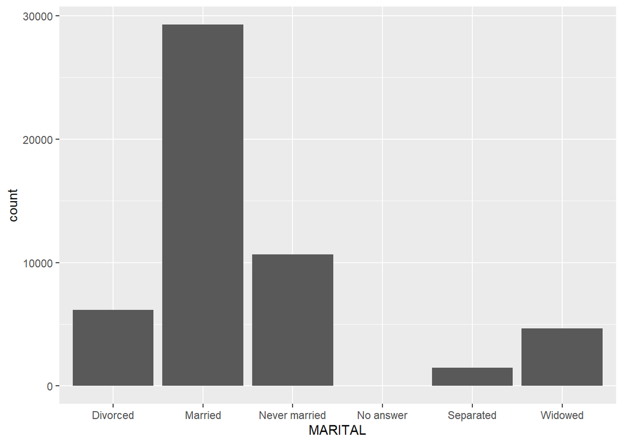

```r
ggplot(filtered_HAPPY, aes(x=MARITAL)) + geom_bar()
```

4. Does party affiliation affect the relationship you found in the last question?

```r
library(dplyr)
library(ggplot2)

filtered_HAPPY_Married <- newdat %>%
  filter(HAPPINESS %in% c("Very happy", "Pretty happy") & MARITAL == 'Married') %>%
  group_by(POLIPARTY)

filtered_HAPPY_Married$POLIPARTY <- factor(filtered_HAPPY_Married$POLIPARTY, levels = c('Strong democrat', 'Ind,near dem','Independent','Ind,near rep','Strong republican','Not str democrat','Not str republican','Other party','No answer','Don\'t know'))

filtered_HAPPY_Married[order(filtered_HAPPY_Married$POLIPARTY),]
```

```
## # A tibble: 29,285 x 8
## # Groups:   POLIPARTY [10]
##     YEAR    ID MARITAL SCHYEAR SEX    POLIPARTY       HAPPINESS    BALLOT
##    <dbl> <dbl> <chr>   <chr>   <chr>  <fct>           <chr>        <chr>
##  1  1972     5 Married 12      Female Strong democrat Pretty happy Not applicab~
##  2  1972    10 Married 12      Female Strong democrat Pretty happy Not applicab~
##  3  1972    11 Married 13      Female Strong democrat Pretty happy Not applicab~
##  4  1972    13 Married 9       Male   Strong democrat Pretty happy Not applicab~
##  5  1972    15 Married 9       Male   Strong democrat Very happy   Not applicab~
##  6  1972    51 Married 10      Male   Strong democrat Pretty happy Not applicab~
##  7  1972    55 Married 10      Female Strong democrat Very happy   Not applicab~
##  8  1972    57 Married 14      Female Strong democrat Pretty happy Not applicab~
##  9  1972    58 Married 12      Female Strong democrat Pretty happy Not applicab~
## 10  1972    59 Married 12      Female Strong democrat Very happy   Not applicab~
## # ... with 29,275 more rows
```

```r
countHappy <- count(filtered_HAPPY_Married)
countHappy
```

```
## # A tibble: 10 x 2
## # Groups:   POLIPARTY [10]
##    POLIPARTY              n
##    <fct>              <int>
##  1 Strong democrat     4141
##  2 Ind,near dem        3196
##  3 Independent         3919
##  4 Ind,near rep        2823
##  5 Strong republican   3402
##  6 Not str democrat    5961
##  7 Not str republican  5250
##  8 Other party          450
##  9 No answer            137
## 10 Don't know             6
```

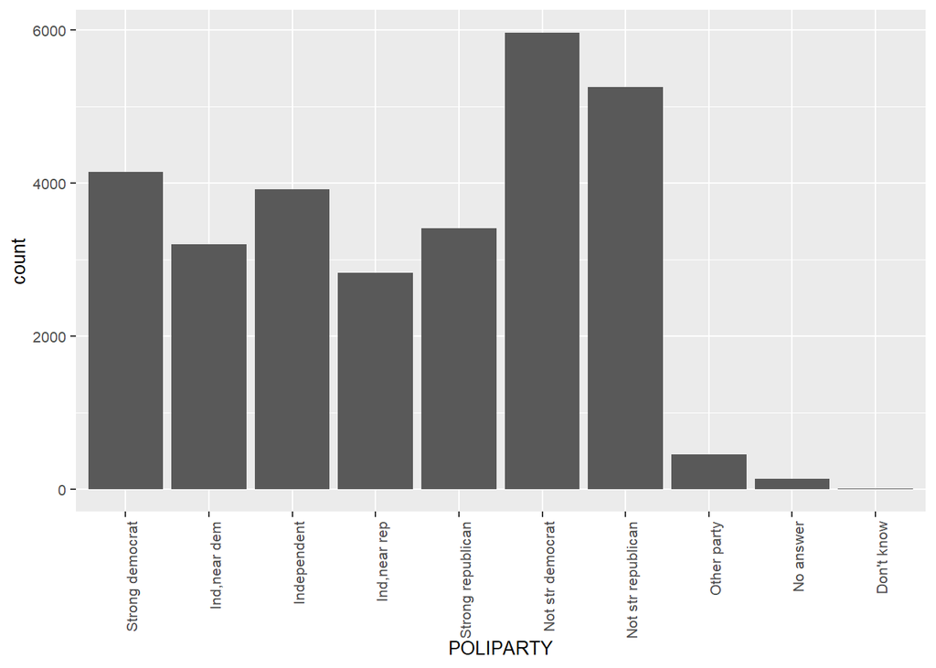

```r
ggplot(filtered_HAPPY_Married, aes(x=POLIPARTY)) + geom_bar() + theme(text = element_text(size = 10), axis.text.x = element_text(angle = 90, hjust =1))
```

We induced that married people are likely to be happier than others, so to verify the exact reaction from the party affiliation, I filtered out only the people who are happy and married. From that point, democrat advocates seem to be happier on the left side of the chart, however, people who are ‘not strong democrat’ are happier than the opposite. In conclusion, I would say affiliation to the party does not have meaningful relations to happiness.

- **5. Explore an interesting question (not covered by the previous questions), and answer the question using the GSS data.**

How does the gender affects in happiness in a couple?

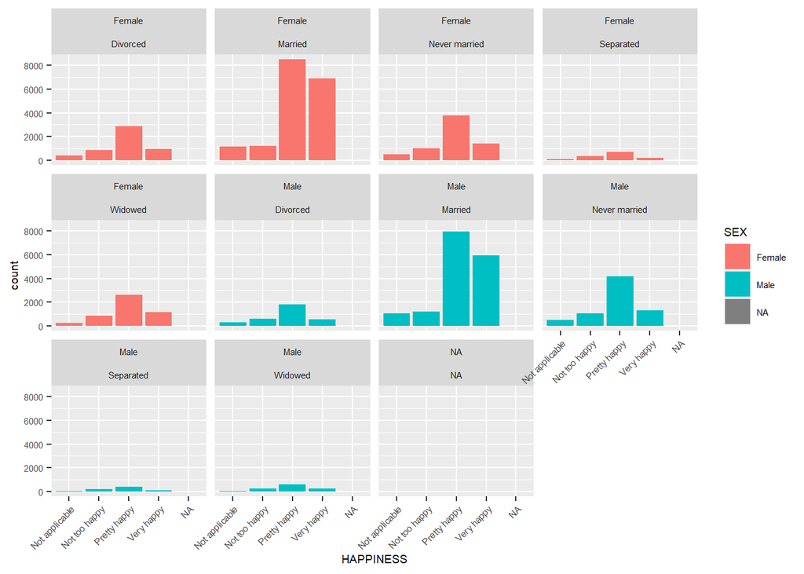

```r
library(dplyr)
library(ggplot2)

newdat <- newdat[!newdat$MARITAL %in% c('No answer', 'Don\'t know', 'NA'),]

newdat <- newdat[!newdat$HAPPINESS %in% c('No answer', 'Don\'t know', 'NA'),]

newdat <- newdat[!(newdat$SEX %in% c('No answer', 'Don\'t know', 'NA')),]

ggplot(newdat, aes(x=HAPPINESS, fill = SEX)) +geom_bar() + theme(text = element_text(size = 7), axis.text.x = element_text(angle = 45, hjust =1)) + facet_wrap(~SEX +MARITAL)
```